# Data Analysis

Jonathan Yuquimpo

01-11-21

## Raw Data

Snippet of data file used for analysis.  
rt: response time  
rwdType: associated value of colored item (if any)

0. No value (black)
1. Low value
2. High value

tgtPos: serial position of target item

0. 1st position
1. 2nd position
2. 3rd position
3. New item (for false alarms)

0. 1st position
1. 2nd position
2. 3rd position
3. New item (for false alarms)

colMatch: Does the color item match the target item?

```
## # A tibble: 5,815 x 7
##    subID correct    rt rwdType tgtPos colPos colMatch
##    <fct> <lgl>   <dbl> <fct>   <chr>  <chr>  <chr>
##  1 c1z   TRUE     618. 1       0      2      1
##  2 c1z   TRUE     599. 0       3      3      0
##  3 c1z   TRUE     650. 0       3      3      0
##  4 c1z   TRUE     806. 0       3      3      0
##  5 c1z   TRUE     641. 2       3      0      1
##  6 c1z   FALSE    810. 1       0      2      1
##  7 c1z   FALSE    690. 0       0      3      0
##  8 c1z   TRUE     385. 1       0      1      1
##  9 c1z   TRUE     912. 2       0      1      1
## 10 c1z   FALSE   1031. 2       1      2      1
## 11 c1z   TRUE     408  1       2      2      2
## 12 c1z   TRUE     863  2       1      0      1
## 13 c1z   TRUE     704. 0       3      3      0
## 14 c1z   TRUE     792. 0       2      3      0
## 15 c1z   TRUE     502. 0       2      3      0
## 16 c1z   TRUE     871. 2       2      1      1
## 17 c1z   TRUE     624. 0       2      3      0
## 18 c1z   TRUE     527. 0       3      3      0
## 19 c1z   TRUE     800. 2       3      1      1
## 20 c1z   FALSE   1125. 1       1      2      1
## # ... with 5,795 more rows
```

## Filtered Data

For each participant, the number of hits, misses, false alarms, and rejections is totaled and used to compute hit rate and false alarm rate. The 1/2N correction is then applied to hit and false alarm rate which yields the HR and FA columns. Those values are then used to compute dprime and criterion for each reward condition (rwd=0, 1, or 2)

```
## # A tibble: 25 x 14
##    subID  hits  miss  fAlm  rejt hitSum hitRate    HR fAlmSum fAlmRate     FA dprime criterion rwd
##    <fct> <int> <int> <int> <int>  <int>   <dbl> <dbl>   <int>    <dbl>  <dbl>  <dbl>     <dbl> <fct>
##  1 111      18     0     2    33     18   1     0.972      35   0.0571 0.0571  3.49     -0.168 1
##  2 15n      15     3    13    23     18   0.833 0.833      36   0.361  0.361   1.32     -0.306 1
##  3 42y      11     7     7    29     18   0.611 0.611      36   0.194  0.194   1.14      0.290 1
##  4 5hn      10     6     8    24     16   0.625 0.625      32   0.25   0.25    0.993     0.178 1
##  5 5qj      16     1     9    27     17   0.941 0.941      36   0.25   0.25    2.24     -0.445 1
##  6 ayv      10     6     7    29     16   0.625 0.625      36   0.194  0.194   1.18      0.271 1
##  7 c1z      10     8     7    29     18   0.556 0.556      36   0.194  0.194   1.00      0.361 1
##  8 c9o       8     8     3    18     16   0.5   0.5        21   0.143  0.143   1.07      0.534 1
##  9 cdy      15     3     8    27     18   0.833 0.833      35   0.229  0.229   1.71     -0.112 1
## 10 fw6      14     4    14    22     18   0.778 0.778      36   0.389  0.389   1.05     -0.241 1
## # ... with 15 more rows
```

```
## # A tibble: 25 x 14
##    subID  hits  miss  fAlm  rejt hitSum hitRate    HR fAlmSum fAlmRate    FA dprime criterion rwd
##    <fct> <int> <int> <int> <int>  <int>   <dbl> <dbl>   <int>    <dbl> <dbl>  <dbl>     <dbl> <fct>
##  1 111      17     1     4    32     18   0.944 0.944      36    0.111 0.111   2.81   -0.186  2
##  2 15n      16     2    12    24     18   0.889 0.889      36    0.333 0.333   1.65   -0.395  2
##  3 42y      13     5    12    24     18   0.722 0.722      36    0.333 0.333   1.02   -0.0794 2
##  4 5hn      12     4     4    29     16   0.75  0.75       33    0.121 0.121   1.84    0.247  2
##  5 5qj      12     6     9    27     18   0.667 0.667      36    0.25  0.25    1.11    0.122  2
##  6 ayv      16     2     5    31     18   0.889 0.889      36    0.139 0.139   2.31   -0.0677 2
##  7 c1z      15     3     8    28     18   0.833 0.833      36    0.222 0.222   1.73   -0.101  2
##  8 c9o       9     2     9    14     11   0.818 0.818      23    0.391 0.391   1.18   -0.316  2
##  9 cdy      15     3     7    29     18   0.833 0.833      36    0.194 0.194   1.83   -0.0529 2
## 10 fw6      14     4    14    22     18   0.778 0.778      36    0.389 0.389   1.05   -0.241  2
## # ... with 15 more rows
```

```
## # A tibble: 25 x 14
##    subID  hits  miss  fAlm  rejt hitSum hitRate    HR fAlmSum fAlmRate     FA dprime criterion rwd
##    <fct> <int> <int> <int> <int>  <int>   <dbl> <dbl>   <int>    <dbl>  <dbl>  <dbl>     <dbl> <fct>
##  1 111      12     0     1    23     12   1     0.958      24   0.0417 0.0417  3.46  -2.22e-16 0
##  2 15n      10     2     4    20     12   0.833 0.833      24   0.167  0.167   1.93   0        0
##  3 42y      10     2     4    20     12   0.833 0.833      24   0.167  0.167   1.93   0        0
##  4 5hn       6     6     3    19     12   0.5   0.5        22   0.136  0.136   1.10   5.48e- 1 0
##  5 5qj       8     4     7    17     12   0.667 0.667      24   0.292  0.292   0.979  5.89e- 2 0
##  6 ayv       9     3     5    18     12   0.75  0.75       23   0.217  0.217   1.46   5.33e- 2 0
##  7 c1z       9     3     3    21     12   0.75  0.75       24   0.125  0.125   1.82   2.38e- 1 0
##  8 c9o       1     3     5     9      4   0.25  0.25       14   0.357  0.357  -0.308  5.20e- 1 0
##  9 cdy       9     3     4    20     12   0.75  0.75       24   0.167  0.167   1.64   1.46e- 1 0
## 10 fw6       9     3     6    18     12   0.75  0.75       24   0.25   0.25    1.35   0        0
## # ... with 15 more rows
```

## Computations for graphs

For each variable, standard error is computed within-subjects using the Rmisc package. See here for more info

```
##   rwd      mean         sd         se         ci        condition
## 1   2 0.7631941 0.13893437 0.02778687 0.05734929         Hit Rate
## 2   1 0.7579608 0.10979047 0.02195809 0.04531928         Hit Rate
## 3   0 0.7393939 0.11420552 0.02284110 0.04714172         Hit Rate
## 4   2 0.2490761 0.06879104 0.01375821 0.02839555 False Alarm Rate
## 5   1 0.2477467 0.07553511 0.01510702 0.03117936 False Alarm Rate
## 6   0 0.2367561 0.08634564 0.01726913 0.03564173 False Alarm Rate
```

```
##   rwd  N   dprime        sd         se       ci
## 1   2 25 1.489229 0.5526604 0.11053208 0.228127
## 2   1 25 1.533687 0.4582929 0.09165859 0.189174
## 3   0 25 1.488702 0.4756194 0.09512388 0.196326
```

```
##   rwd  N   criterion        sd         se         ci
## 1   2 25 -0.01648927 0.2575162 0.05150323 0.10629745
## 2   1 25 -0.04722726 0.2609477 0.05218954 0.10771392
## 3   0 25  0.02231084 0.2371378 0.04742757 0.09788569
```

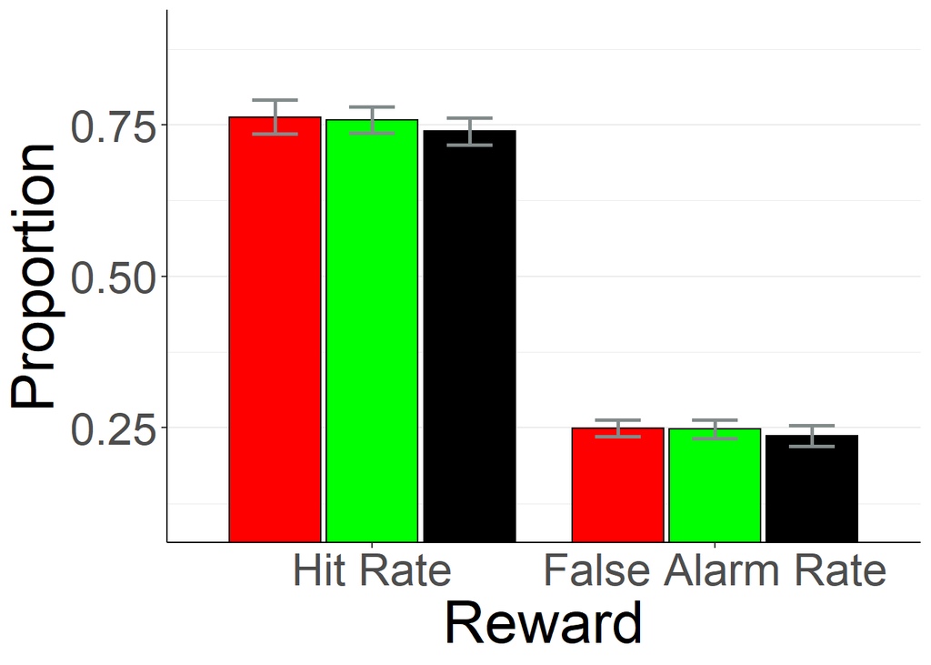

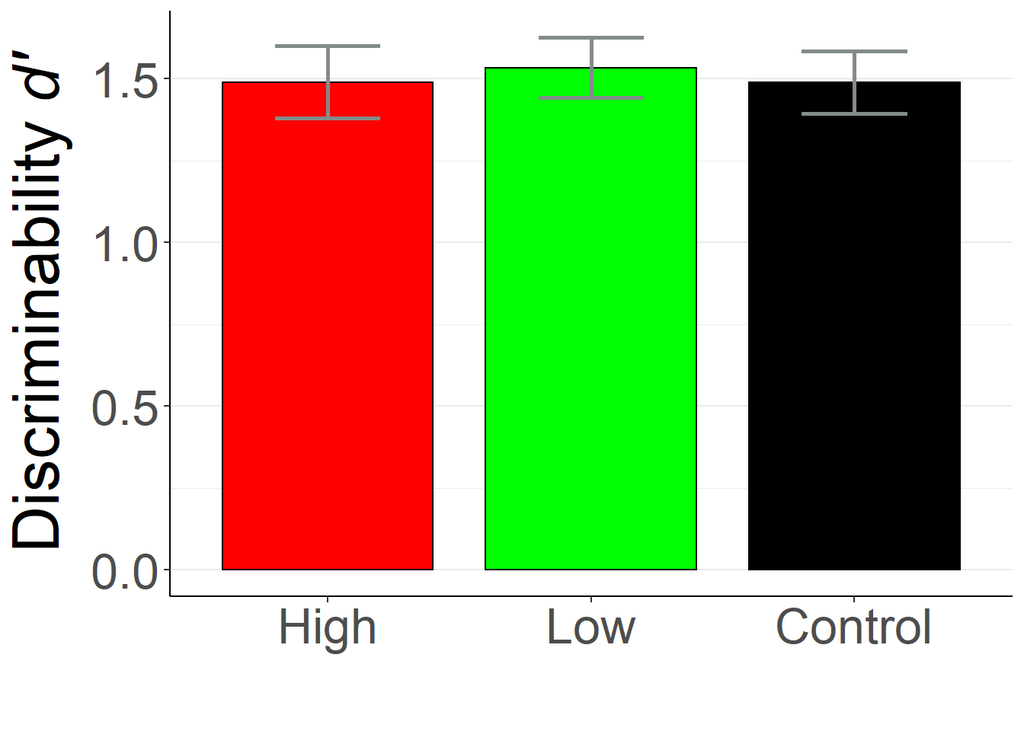

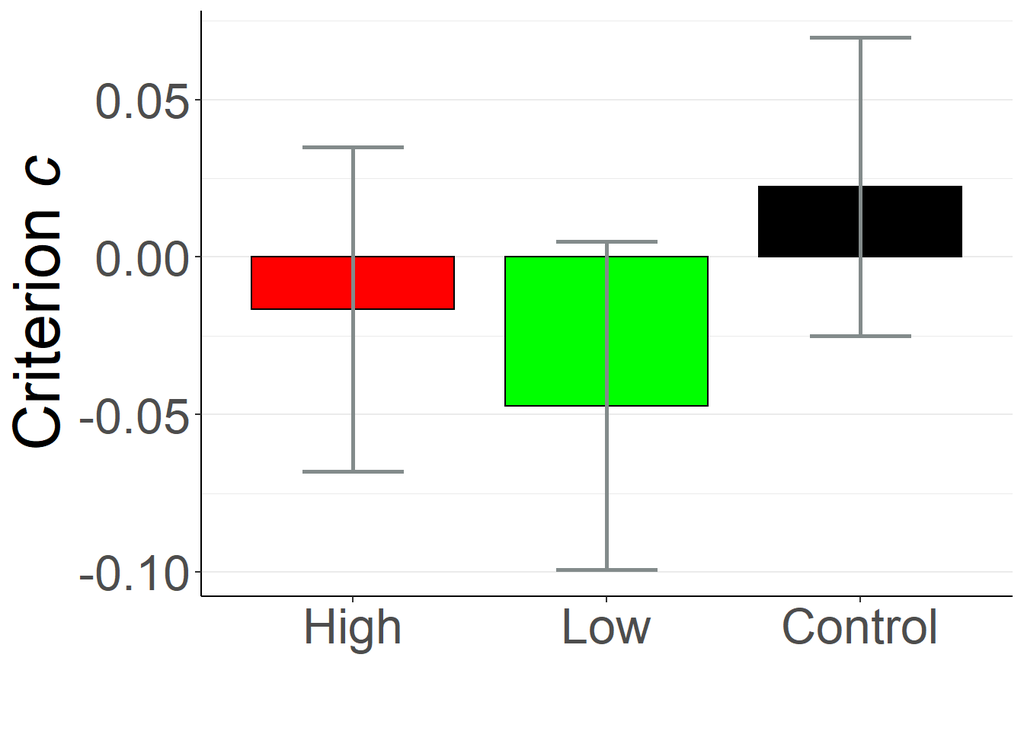